# exam

## Examen final

- Ce notebook est à soumettre sur [Educnet](https://educnet.enpc.fr/mod/assign/view.php?id=70941) avant 11h30.
- L’examen comporte trois exercices indépendants. Dans chaque exercice, les cellules peuvent éventuellement dependre des cellules précèdentes.
- Afin de faciliter l'évaluation de votre code, ne pas changer les signatures des fonctions à implémenter.
- La cellule ci-dessous importe les bibliothèques utilisées dans ce notebook. Ce sont *a priori* des bibliothèques déjà présentes dans l'installation de base de Julia ou déjà installées en TD. Si une ou plusieurs d'entre elles manquent sur votre machine, vous êtes invités à les installer au préalable dans le gestionnaire de bibliothèques d'une console.

```julia
using ForwardDiff
using LaTeXStrings
using LinearAlgebra
using Plots
using Polynomials
using Random

Plots.default(titlefontsize=12,
              xlabelfontsize=10,
              ylabelfontsize=10,
              legendfontsize=10,
              xtickfontsize=10,
              ytickfontsize=10)
```

### [Exercice 1] Intégration par interpolation

Le but de cet exercice est de calculer l'intégrale de la fonction $f \colon [-5, \,5] \to \mathbb{R} $ donnée par

$$ f (x) = \log(1 + |x| - x^3 + x^4). $$

Pour cela, nous vous proposons d'interpoler cette fonction par un polynome sur l'intervalle $[-5, \, 5]$, puis d'intégrer ce dernier.

1. Ecrire une fonction `interpolate(func, d, a)` qui retourne le polynôme $p$ (de type `Polynomial` de la bibliothèque `Polynomials.jl`) résultant de l'interpolation polyonmiale de la fonction `func` sur l'intervalle $[-a, a]$ de degré $d$. Pour cela, vous pourrez utiliser la fonction `fit` de la bibliothèque `Polynomials.jl`, et choisir les nœuds d'interpolation de la manière qui vous semble la mieux adaptée.

```julia
f(x) = log(1 + abs(x) - x^3 + x^4)

function interpolate(func, d, a)
    ### BEGIN SOLUTION
    chebyshev_nodes(k, n) = cospi((2k - 1) / (2n))
    x = a * chebyshev_nodes.(1:d+1, d+1)
    y = func.(x)
    p = fit(x, y)
    ### END SOLUTION
    return p
end;
```

```julia
@assert typeof(interpolate(f, 20, 5)) <: Polynomial
@assert length(interpolate(f, 20, 5).coeffs) == 21
@assert begin xs = LinRange(-1, 1, 200); interpolate(cos, 20, 1).(xs) .- cos.(xs) |> maximum end ≤ 1e-14
@assert begin xs = LinRange(-1, 1, 200); func = x -> x^3; p = interpolate(func, 20, 1); sum(abs2, p.(xs) - func.(xs)) end ≤ 1e-14
```

2. Illustrer sur un même graphique la fonction `f` définie ci-dessus, ainsi que son interpolation de degré 20.

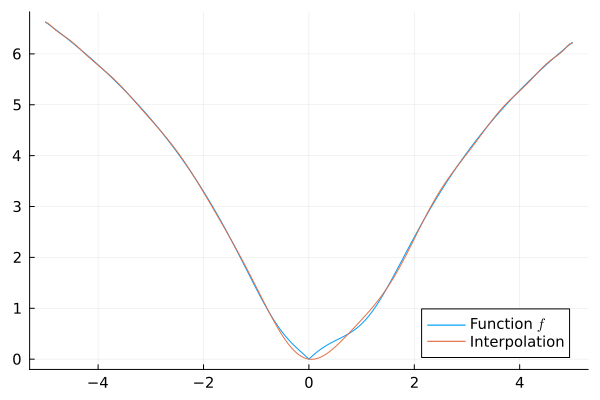

```julia
# ### BEGIN SOLUTION
x = LinRange(-5, 5, 201)
p = interpolate(f, 20, 5)
plot(x, f, label=L"Function $f$")
plot!(x, p.(x), label="Interpolation")
# ### END SOLUTION
```

3. Écrire une fonction `integrate_via_interp(func, d, a)` qui retourne une approximation de l'intégrale $$ \int_{-a}^a \mathrm{func}(x) \, \mathrm{d} x\, , $$ en calculant d'abord une interpolation de degré `d` de la fonction passée en argument, puis en intégrant cette dernière de manière exacte. Pour cela, on pourra utiliser la fonction `integrate` de la bibliothèque `Polynomials.jl`, qui permet de calculer la primitve d'un polynôme:

   ```
       P = integrate(p)
   ```

```julia
function integrate_via_interp(func, d, a)
    ### BEGIN SOLUTION
    p = interpolate(func, d, a)
    P = integrate(p)
    return P(a) - P(-a)
    ### END SOLUTION
end;
```

```julia
funcs = [x -> 1, x -> x, x -> x^2, x -> x^3]
@assert integrate_via_interp.(funcs, 20, 1) ≈ [2, 0, 2/3, 0]
@assert integrate_via_interp(exp, 20, 1) ≈ exp(1) - exp(-1)
@assert integrate_via_interp(cos, 20, 5) ≈ sin(5) - sin(-5)
@assert integrate_via_interp(x -> 1 + 3x^3, 5, 1) ≈ 2.0
@assert abs(integrate_via_interp(f, 20, 5) - 34.070458) ≤ 0.5
```

### [Exercice 2] Une méthode d'ordre élevé pour les équations non-linéaires

Le but de cet exercice est de mettre en œuvre une méthode de résolution pour l'équation non-linéaire **scalaire** suivante : $$ f(x) = 0, \qquad f \colon \mathbb R \to \mathbb R $$ Inspiré par la méthode de Newton-Raphson, qui est basée sur une approximation affine de $f$ à chaque itération, on a l'idée de définir un schéma itératif basé sur des approximations quadratiques de $f$. Plus précisément, on considère la méthode itérative qui consiste à définir, étant donné une approximation $x_k$, l'approximation $x_{k+1}$ de la manière suivante :

- Considérons le polynôme de Taylor quadratique $p_k$ approximant $f$ autour de $x_k$: $$ p_k(x) = \frac{f''(x_k)}{2} (x - x_k)^2 + f'(x_k) (x - x_k) + f(x_k). $$
- Si ce polynôme admet deux racines $r_1 \leqslant r_2$ (éventuellement égales), alors on pose $x_{k+1} = r_1$ si $|x_k - r_1| \leqslant |x_k - r_2|$, et $x_{k+1} = r_2$ sinon.
- Si ce polynôme n'admet pas de racine, on considérera que la méthode ne fonctionne pas. La fonction à implémenter ci-dessous devra retourner `nothing`.
1. Implémenter la méthode suggérée et retourner l'ensemble des itérations, y compris le point initial `x` passé en argument et l'approximation finale, dans un vecteur `xs`. On supposera que l'argument `x` est un nombre flottant (`Float16`, `Float32`, `Float64` ou `BigFloat`), et on demande de retourner dans le vecteur `xs` des flottants du même type. Ici `f` est une fonction, `df` est sa dérivée, et `ddf` sa dérivée seconde.

```julia
function super_newton(x, f, df, ddf; maxiter=100, ε = 1e-12)
    xs = [x]
    ### BEGIN SOLUTION
    for n in 1:maxiter
        abs(f(x)) < ε && return xs
        a, b, c = ddf(x), df(x), f(x)
        Δ = b^2 - 2*a*c
        Δ < 0 && return nothing
        x1, x2 = x + (-b - √Δ) / a, x + (-b + √Δ) / a
        x = abs(x - x1) < abs(x - x2) ? x1 : x2
        push!(xs, x)
    end
    ### END SOLUTION
    return xs
end;
```

```julia
funs = x -> exp(x) - 2, exp, exp
@assert super_newton(1., funs...) |> typeof === Vector{Float64}
@assert super_newton(1.f0, funs...) |> typeof === Vector{Float32}
@assert super_newton(BigFloat(1.), funs...) |> typeof === Vector{BigFloat}
@assert super_newton(1., funs...)[end] ≈ log(2)
@assert super_newton(3., x -> x^3 - x - 6, x -> 3*x^2 - 1, x -> 6x)[end] ≈ 2
@assert super_newton(1., x -> sin(x) - .5, cos, x -> -sin(x))[end] ≈ π/6
@assert super_newton(1., x -> x^3, x -> 3x^2, x -> 6x) === nothing
```

2. Faire un graphique illustrant l'évolution de l'erreur dans le cas où $f(x) = x^3 - 2$. Initialiser l'itération à $x_0 = 1$, et utiliser le format `BigFloat` avec une grande précision, ainsi qu'une très petite tolérance $ε = 10^{-200}$, afin d'illustrer la convergence aussi clairement que possible. Pour éviter d'encombrer le namespace global, on encapsulera le code du graphique dans une fonction.

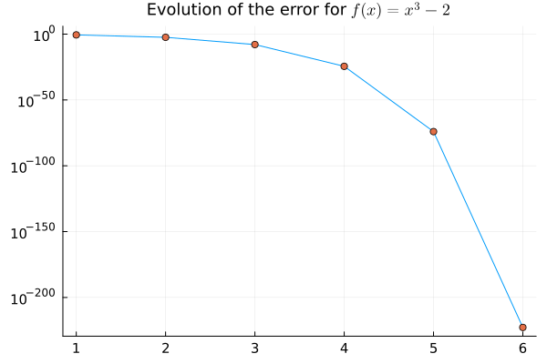

```julia
# Augmentation de la précision pour le format BigFloat
setprecision(1000, base=10)

# Fonction dont on cherche une racine
f(x) = x^3 - 2.0

function my_plot_error()
    p = plot(title=L"Evolution of the error for $f(x) = x^3 - 2$")
    ### BEGIN SOLUTION
    x = BigFloat(1)
    x∞ = cbrt(BigFloat(2.0))
    df(x) = 3x^2
    ddf(x) = 6x
    xs = super_newton(x, f, df, ddf; ε = 1e-200)
    yplot = abs.(xs .- x∞)
    plot!(yplot, yscale=:log10, label=nothing)
    scatter!(yplot, yscale=:log10, label=nothing)
    ### END SOLUTION
    return p
end
my_plot_error()
```

3. Supposons qu'une suite $(x_0, x_1, \dotsc)$, dont on ne connaît qu'un nombre fini d'éléments $(x_0, \dotsc, x_K)$, converge à l'ordre $q$ vers une limite $x_{*} \in \mathbb R$, c'est à dire que $$ \lim_{k \to \infty} \frac{|x_{k+1} - x_{\infty}|}{|x_{k} - x_{\infty}|^q} \in \mathbb R. $$ Écrire une fonction `estimate_order(xs, x∞)` permettant d'estimer l'ordre de convergence $q$.

```julia
function estimate_order(xs, x∞)
    ### BEGIN SOLUTION
    logerr = (log∘abs).(xs .- x∞)
    p = fit(logerr[1:end-1], logerr[2:end], 1)
    return p[1]
    ### END SOLUTION
end;
```

```julia
@assert estimate_order([1e-1, 1e-2, 1e-4, 1e-8, 1e-16], 0.) ≈ 2
@assert estimate_order([1e-1, 1e-3, 1e-9, 1e-27], 0.) ≈ 3
@assert estimate_order([1e-1, 1e-2, 1e-3, 1e-4], 0.) ≈ 1

# Estimation de l'ordre de convergence de la méthode `super_newton`
function get_order_super_newton()
    x∞ = cbrt(BigFloat(2.0))
    xs = super_newton(BigFloat(2.), x -> x^3 - 2, x -> 3x^2, x -> 6x; ε = 1e-200)
    q = round(Float64(estimate_order(xs, x∞)), sigdigits=5)
end
println("Order of the proposed method: ", get_order_super_newton())
### BEGIN HIDDEN TESTS
@assert round.(Int, get_order_super_newton()) == 3
### END HIDDEN TESTS
```

```
Order of the proposed method: 3.0022
```

4. Pour éviter de calculer des dérivées manuellement, on souhaite utiliser la différentiation automatique. Écrire une fonction `super_newton_auto` implémentant la méthode tout en exploitant la différentiation automatique. Il peut être utile pour ce faire d'utiliser la fonction `ForwardDiff.derivative`, et de réutiliser la méthode `super_newton` définie ci-dessus.

```julia
function super_newton_auto(x, f; maxiter=100, ε=1e-12)
    ### BEGIN SOLUTION
    df(x) = ForwardDiff.derivative(f, x)
    ddf(x) = ForwardDiff.derivative(df, x)
    return super_newton(x, f, df, ddf; maxiter=maxiter, ε=ε)
    ### END SOLUTION
end;
```

```julia
@assert super_newton_auto(1., x -> exp(x) - 2) |> typeof === Vector{Float64}
@assert super_newton_auto(1., x -> exp(x) - 2)[end] ≈ log(2)
@assert super_newton_auto(1., x -> sin(x) - .5)[end] ≈ π/6
@assert super_newton_auto(3., x -> x^3 - x - 6)[end] ≈ 2
```

### [Exercice 3] Équation de Lotka-Volterra

Dans le cadre d’une étude écologique sur une île isolée, on aimerait étudier l’interaction entre deux populations animales :

- 🐇 des **lapins sauvages**, qui se reproduisent rapidement en l’absence de prédateurs,
- 🦊 des **renards**, qui se nourrissent exclusivement de lapins.

Leur dynamique est modélisée par les équations classiques de **Lotka-Volterra** :

$$ \left\{ \begin{aligned} X'(s) &= \alpha \, X(s) - \beta \, X(s)\,Y(s), \\ Y'(s) &= - \gamma \, Y(s) + \delta \, X(s)\,Y(s), \end{aligned} \right. $$

où :

- $s$ représente le temps.
- $X(s)$ représente la population de **lapins** à l’instant $ s $,
- $Y(s)$ représente la population de **renards** à l’instant $ s $,
- $\alpha$ est le **taux de reproduction** naturelle des lapins en l’absence de renards,
- $\beta$ est la contribution de chaque renard au **taux de mortalité** des lapins,
- $\delta$ est la contribution de chaque lapin au **taux de reproduction** des renards,
- $\gamma$ est le **taux de mortalité** naturelle des renards en l’absence de nourriture.

Ce modèle permet d’analyser les cycles prédateur-proie typiques dans les écosystèmes fermés. Il est simple de montrer que l'unique état d'équilibre non trivial est donné par $(X_{\rm eq}, Y_{\rm eq}) = (\gamma/\delta, \alpha/\beta)$. Afin d'éliminer certains paramètres, on a l'idée d'introduire les variables adimensionnées $X/X_{\rm eq}$ et $Y/Y_{\rm eq}$. Pour simplifier encore davantage, on prendra comme nouvelle unité temporelle la constante de temps associée à l'extinction exponentielle de renards en l'absence de lapins, ce qui revient à poser $x(t) = X(t/γ)/X_{\rm eq}$ et $y(t) = Y(t/γ)/Y_{\rm eq}$. L'évolution du couple $(x, y)$ est alors donnée par $$ \left\{ \begin{aligned} x'(t) &= r \, x(t) - r \, x(t)\,y(t), \\ y'(t) &= - y(t) + x(t)\,y(t), \end{aligned} \right. \qquad r := \frac{\alpha}{\gamma} \tag{Lotka-Volterra} $$ On supposera dans la première partie de l'exercice que tous les paramètres α,β,γ,δ sont scalaires avec de plus $α = γ$, de sorte que $r = 1$. Dans la seconde partie, on adoptera un modèle plus réaliste dans lequel $α$ dépend de $x$.

1. En posant $\mathbf Z := (x, y)^\top$, on peut réécrire l'équation de (Lotka-Volterra) sous la forme générique suivante : $$ \mathbf Z'(t) = \mathbf f\bigl(t, \mathbf Z(s)\bigr). \tag{Generic-ODE} $$ Écrire la fonction $\mathbf f$ sous forme d'une fonction Julia `f(t, Z)`.

```julia
function f(t, Z)
    ### BEGIN SOLUTION
    x, y = Z
    return [x - x*y, -y + x*y]
    ### END SOLUTION
end;
```

```julia
@assert f(1, [0, 1]) ≈ [0, -1]
@assert f(1, [1, 0]) ≈ [1, 0]
@assert f(1, [5, 2]) ≈ [5 - 10, -2 + 10]
```

2. Écrire une fonction `heun3(g, tₙ, Zₙ, Δ)` implémentant un pas de temps de taille $\Delta$ de la méthode de Heun d'ordre 3 pour une équation différentielle générique de la forme $\mathbf Z' = \mathbf g(t, \mathbf Z)$. Cette méthode est basée sur l'itération suivante: $$ \mathbf Z_{n+1} = \mathbf Z_n + \frac{\Delta}{4}\left(\mathbf k_1 + 3 \mathbf k_3 \right), $$ où \begin{align*} \mathbf k_1 &= \ \mathbf g(t_n, \mathbf Z_n), \\ \mathbf k_2 &= \ \mathbf g\!\left(t_n + \frac{\Delta}{3}, \mathbf Z_n + \frac{\Delta}{3} \mathbf k_1\right), \\ \mathbf k_3 &= \ \mathbf g\!\left(t_n + \frac{2\Delta}{3}, \mathbf Z_n + \frac{2\Delta}{3} \mathbf k_2\right), \\ \end{align*} La fonction devra renvoyer $\mathbf Z_{n+1}$.

```julia
function heun3(g, tₙ, Zₙ, Δ)
    ### BEGIN SOLUTION
    k₁ = g(tₙ,       Zₙ           )
    k₂ = g(tₙ + Δ/3, Zₙ + Δ/3 * k₁)
    k₃ = g(tₙ + 2Δ/3, Zₙ + 2Δ/3 * k₂)
    return Zₙ + Δ/4 * (k₁ + 3k₃)
    ### END SOLUTION
end;
```

```julia
@assert heun3((t, Z) -> [1.],0., [0.], 1.) ≈ [1.0]
@assert heun3((t, Z) -> [t], 1., [0.], 1.)  ≈ [3/2]
@assert heun3((t, Z) -> [1.; t; t^2], 0., [2.; 2.; 2.], 1.) ≈ [3., 5/2, 7/3]
```

3. Écrire une fonction `solve_ode(g, Z₀, Δ, niter)` pour résoudre (Generic-ODE) en effectuant `niter` itérations de la méthode de Heun d'ordre 3 avec un pas de temps fixe `Δ`. Votre fonction devra renvoyer un vecteur de temps `ts` (comprenant le temps initial, donc de taille `niter + 1`), ainsi qu'un vecteur de vecteurs contenant la solution à ces temps.

```julia
function solve_ode(g, Z₀, Δ, niter)
    ### BEGIN SOLUTION
    ts = (0:niter) * Δ
    Z, Zs = Z₀, [Z₀]
    for t in ts[1:end-1]
        Z = heun3(g, t, Z, Δ)
        push!(Zs, Z)
    end
    return ts, Zs
    ### END SOLUTION
end;
```

```julia
@assert solve_ode(f, [1.0, 0.0], 0.01, 100) |> length == 2
@assert solve_ode(f, [1.0, 0.0], 0.01, 100)[1] |> length == 101
@assert solve_ode(f, [1.0, 0.0], 0.01, 100)[1][101] ≈ 1
@assert solve_ode(f, [1.0, 0.0], 0.01, 100)[1] ≈ 0:.01:1
@assert solve_ode(f, [1.0, 0.0], 0.01, 100)[2] |> x -> sum(z -> z[2], x) == 0.
@assert solve_ode(f, [0.0, 1.0], 0.1, 1000)[2][end][2] ≤ 1e-3
```

4. Écrire une fonction `my_plot_evolution(g, Z₀, Δ, niter)` permettant d'illustrer sur un même graphique l'évolution des populations de lapins et de renards en fonction du temps, pour une condition initiale `Z₀` donnée. Cette fonction prendra explicitement en argument une function `g`, car on l'utilisera plus tard avec un autre modèle d'évolution des populations. La cellule en dessous vous permettra de tester votre code.

```julia
function my_plot_evolution(g, Z₀, Δ, niter)
    x₀, y₀ = Z₀
    p = plot(title="(x₀, y₀) = ($x₀, $y₀)")
    ### BEGIN SOLUTION
    ts, Zs = solve_ode(g, Z₀, Δ, niter)
    xs, ys = first.(Zs), last.(Zs)
    plot!(ts, xs, label="Lapins")
    plot!(ts, ys, label="Renards")
    ### END SOLUTION
    return p
end;
```

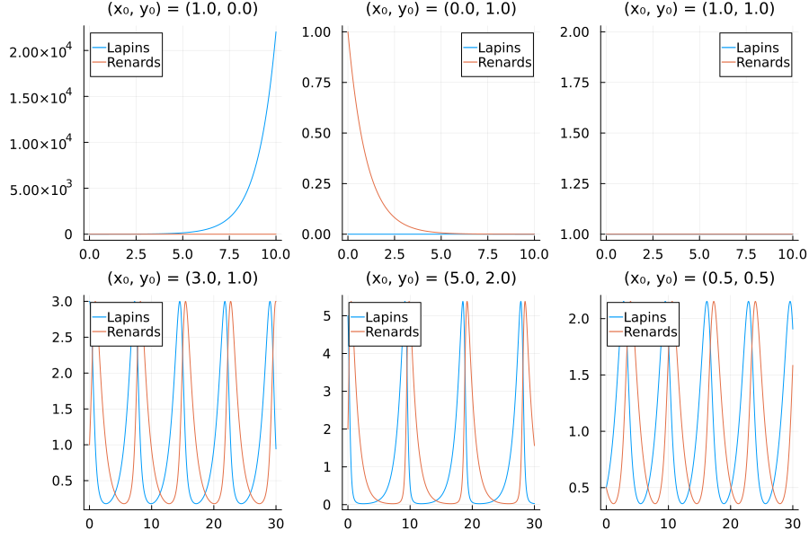

```julia
Δ, niter1, niter2 = .01, 1000, 3000
p1 = my_plot_evolution(f, [1.0, 0.0], Δ, niter1)
p2 = my_plot_evolution(f, [0.0, 1.0], Δ, niter1)
p3 = my_plot_evolution(f, [1.0, 1.0], Δ, niter1)
p4 = my_plot_evolution(f, [3.0, 1.0], Δ, niter2)
p5 = my_plot_evolution(f, [5.0, 2.0], Δ, niter2)
p6 = my_plot_evolution(f, [0.5, 0.5], Δ, niter2)
plot(p1, p2, p3, p4, p5, p6; layout=(2, 3), size=(900, 600))
```

```julia
function my_plot_phase(g, all_Z₀, Δ, niter)
    p = plot(title="Evolution in the phase space")
    ### BEGIN SOLUTION
    for Z₀ in all_Z₀
        x₀, y₀ = Z₀
        _, Zs = solve_ode(g, Z₀, Δ, niter)
        xs, ys = getindex.(Zs, 1), getindex.(Zs, 2)
        plot!(xs, ys, label="(x₀, y₀) = ($x₀, $y₀)")
    end
    ### END SOLUTION
    return p
end;
```

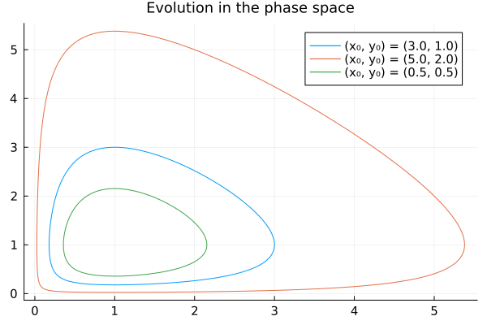

```julia
all_Z₀ = [[3.0, 1.0],
          [5.0, 2.0],
          [0.5, 0.5]]

my_plot_phase(f, all_Z₀, .01, 3000)
```

7. Suite à un problème technique, les données sur les conditions initiales de l’étude écologique ont été perdues. Les populations animales ont néanmoins été observées au temps $t=1$, où elles étaient données par $(x₁, y₁) = (2, 2)$. En se basant sur ce point d'observation et sur le modèle d'évolution de (Lotka-Volterra), estimer les populations au temps $t = 0$. Il peut être utile pour cela d'utiliser la bibliothèque `ForwardDiff.jl`, en particulier la fonction `ForwardDiff.jacobian`.

```
Z₀ = [2.2095710044614583, 0.4962424586387766]
```

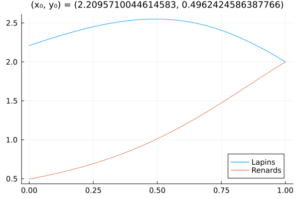

```julia
function recover_initial_data()
    Z₁ = [2., 2.]
    ### BEGIN SOLUTION
    obj(Z) = solve_ode(f, Z, .01, 100)[2][end] - Z₁
    Z₀ = [5., .1]
    for n in 1:10
        Z₀ -= ForwardDiff.jacobian(obj, Z₀)\obj(Z₀)
    end
    ### END SOLUTION
    return Z₀
end

Z₀ = recover_initial_data()
@show Z₀
my_plot_evolution(f, Z₀, .01, 100)
```

```julia
@assert length(Z₀) == 2
### BEGIN HIDDEN TESTS
@assert round.(Z₀, digits=3) ≈ [2.21, 0.496]
### END HIDDEN TESTS
```

8. L'évolution de Lotka-Volterra avec $r = 1$ conserve la quantité $V(x, y) = x - \ln(x) + y - \ln(y)$ (pour mémoire le logarithme népérien est donné par `log` en Julia). Écrire une fonction `calculate_energy_mismatch` retournant, pour la fonction `solve_ode` avec le pas de temps donné en argument, la déviation maximale de l'énergie sur l'intervalle de temps $[0, 1]$. Plus précisément, la fonction devra retourner $$ E(Δ) := \max_{n \in \mathbb N, nΔ \in [0, 1]} \Bigl| V\bigl( x_n, y_n \bigr) - V\bigl( x(0), y(0) \bigr) \Bigr| $$

```julia
V(z) = z[1] - log(z[1]) + z[2] - log(z[2])

function calculate_energy_mismatch(Z₀, Δ)
    ### BEGIN SOLUTION
    niter = floor(Int, 1/Δ)
    ts, Zs = solve_ode(f, Z₀, Δ, niter)
    E = maximum(abs, V.(Zs) .- V(Z₀))
    ### END SOLUTION
    return E
end;
```

```julia
Z₀ = [2.0, 2.0]
@assert calculate_energy_mismatch(Z₀, .1) > 1e-8
@assert calculate_energy_mismatch(Z₀, .1) < 1e-3
@assert calculate_energy_mismatch(Z₀, .01) > 1e-12
@assert calculate_energy_mismatch(Z₀, .01) < 1e-6
@assert calculate_energy_mismatch(Z₀, .001) < 1e8
```

9. Il est possible de montrer que $E(Δ) \propto Δ^q$, de manière approximative. Estimer l'exposant $q$. Pour cela, approximer par une droite la fonction $\log(Δ) \mapsto \log\bigl(E(Δ)\bigr)$, et déduire la valeur de $q$ du coefficient directeur de cette droite.

```julia
function estimate_q()
    ### BEGIN SOLUTION
    Z₀ = [2.0, 2.0]
    Δs = 1 ./ 2 .^(4:10)
    Es = [calculate_energy_mismatch(Z₀, Δ) for Δ in Δs]
    q = fit(log.(Δs), log.(Es), 1)[1]
    ### END SOLUTION
    return q
end;

println("Order of convergence: ", estimate_q())
```

```
Order of convergence: 3.023790725383018
```

```julia
@assert estimate_q() > 0
### BEGIN HIDDEN TESTS
@assert round.(Int, estimate_q()) == 3
### END HIDDEN TESTS
```

10. **On considère à partir de maintenant un modèle plus réaliste**, incluant une saturation du taux de reproduction des lapins lorsque leur population devient trop importante. Concrètement, on considère que le taux de reproduction des lapins est désormais donné par $\widehat α(x) = α (1-\frac{x}{4})$, où $α$ désigne le même paramètre scalaire que précédemment. Ce choix mène aux équations d'évolution suivantes : $$ \left\{ \begin{aligned} x'(t) &= \left( 1 - \frac{x(t)}{4} \right) x(t) - x(t)\,y(t), \\ y'(t) &= - y(t) + x(t)\,y(t). \end{aligned} \right. \tag{Modified-Lotka-Volterra} $$ Avec ce modèle, le nombre de lapins en l'absence de renards ne diverge plus dans la limite $t \to \infty$. Tout comme les équations de Lotka-Volterra classiques étudiées précédemment, les équations (Modified-Lotka-Volterra) peuvent s'écrire sous la forme d'une équation différentielle générique $\mathbf Z' = \mathbf g(t, \mathbf Z)$. Écrire la fonction $\mathbf g$ correspondante sous forme d'une fonction Julia.

```julia
function g(t, Z)
    ### BEGIN SOLUTION
    x, y = Z
    return [x*(1-x/4) - x * y,  y * (x - 1)]
    ### END SOLUTION
end;
```

```julia
@assert g(1, [0, 1]) ≈ [0, -1]
@assert g(0, [4, 1]) ≈ [-4, 3]
@assert g(10, [8, 2]) ≈ [-24.0, 14.0]
```

Il est possible de montrer qu'avec ce nouveau modèle, pour toute condition initiale telle que $x₀ > 0$ et $y₀ > 0$, les populations de lapins et de renards tendent vers l'équilibre $(x_{\infty}, y_{\infty}) := \bigl( 1, \frac{3}{4} \bigr)$ dans la limite $t \to \infty$, comme illustré ci-dessous.

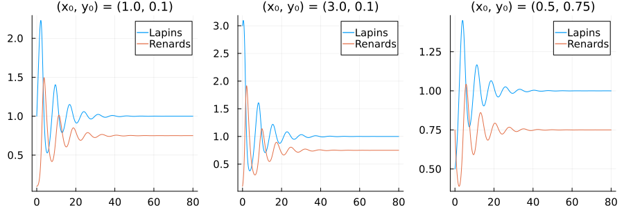

```julia
Δ, niter = .01, 8_000
p1 = my_plot_evolution(g, [1.0, .1], Δ, niter)
p2 = my_plot_evolution(g, [3.0, .1], Δ, niter)
p3 = my_plot_evolution(g, [0.5, .75], Δ, niter)
plot(p1, p2, p3; layout=(1, 3), size=(900, 300))
```

11. On suppose maintenant que les populations animales de l'île sont à l'équilibre pour $t < 0$, donc en particulier $x(0^-) = x_{\infty}$ et $y(0^-) = y_{\infty}$. Afin de repeupler les îles voisines, des lapins sont extraits de l'île considérée au temps $t = 0$.

    Soucieux de préserver l'équilibre écologique de l'île, les habitants souhaitent déterminer la proportion maximale de lapins pouvant être extraite tout en s'assurant que la population de **renards** ne s'écarte jamais (pour aucun $t \geq 0$) de plus de 20% de sa valeur d'équilibre $y_{\infty} = \frac{3}{4}$.

    Pour cela, commencer par écrire une fonction `max_fox_deviation` afin d'estimer la déviation maximale de la population de renards, en proportion (la fonction devra donc retourner un réel compris entre 0 et 1).

```julia
function max_fox_deviation(x₀)
    ### BEGIN SOLUTION
    x∞, y∞ = 1, .75
    Z₀ = [x₀, y∞]
    Δ, niter = .01, 10_000
    ts, Zs = solve_ode(g, Z₀, Δ, niter)
    ys = getindex.(Zs, 2)
    return maximum(abs, ys .- y∞) / y∞
    ### END SOLUTION
end;
```

```julia
@assert max_fox_deviation(0.) ≈ 1.
@assert max_fox_deviation(1.) ≈ 0.
@assert max_fox_deviation(1.e-10) > 1.9
@assert round(max_fox_deviation(0.5), digits=3) ≈ 0.481
```

12. Estimer graphiquement la valeur minimale de $x₀$ qui est admissible. On pourra utiliser les fonctions `hline` et `vline` (ou leurs homologues `hline!` et `vline!`) pour tracer des droites horizontales ou verticales.

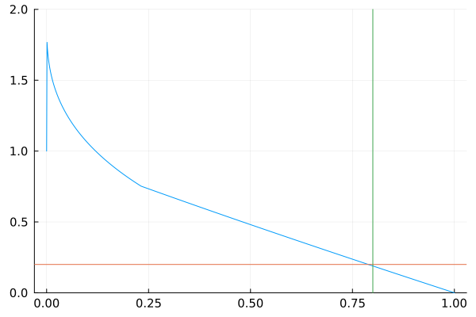

```julia
### BEGIN SOLUTION
x = LinRange(0, 1, 1000)
plot(x, max_fox_deviation.(x), label=nothing)
hline!([.2], label=nothing)
vline!([.8], label=nothing)
ylims!(0, 2.)
### END SOLUTION
```

13. (**Bonus**) Ayant constaté à la question précédente l'existence d'un $x_0$ minimal satisfaisant la contrainte sur la population de renard, on se propose ici de déterminer cette valeur de manière très précise. Pour cela, on suggère de procéder par une méthode de Newton-Raphson s'appuyant sur les nombres duaux. Écrire une fonction `newton_raphson_dual(x, f, maxiter=100; ε = 1e-12)` renvoyant une racine de la fonction `f` en partant d'un point initial `x`.

    **Indication (cliquer pour afficher)**

    On rappelle que l'on peut obtenir simultanément la valeur et la dérivée d'une fonction `f` en `x` par la méthode suivante

    ```
    y = f(ForwardDiff.Dual(x, 1.))
    fx = y.value  # renvoie f(x)
    dfx = y.partials[1]  # renvoie f'(x)
    ```

```julia
function newton_raphson_dual(x, f; maxiter=100, ε = 1e-12)
    ### BEGIN SOLUTION
    for i in 1:maxiter
        y = f(ForwardDiff.Dual(x, 1.))
        x -= y.value/y.partials[1]
        norm(f(x)) < ε && return x
    end
    return nothing
    ### END SOLUTION
end;
```

```julia
@assert newton_raphson_dual(1, x -> x^2 - 2) ≈ √2
@assert newton_raphson_dual(-1, x -> x^2 - 2) ≈ -√2
@assert newton_raphson_dual(1, x -> x^3 - 2) ≈ cbrt(2)
@assert newton_raphson_dual(2, x -> cos(x) - .5) ≈ acos(.5)
```

14. (**Bonus**) À l'aide des fonctions `max_fox_deviation` et `newton_raphson_dual`, déterminer la valeur minimale de `x₀` qui est acceptable, et vérifier cette solution en traçant un graphe présentant l'évolution des populations pour le `x₀` obtenu.

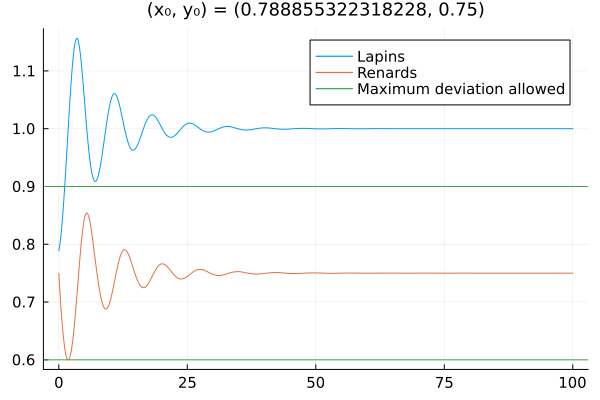

```julia
### BEGIN SOLUTION
x₀ = newton_raphson_dual(.8, x -> max_fox_deviation(x) - .2)
y₀ = .75

Δ, niter = .01, 10_000
my_plot_evolution(g, [x₀, y₀], Δ, niter)
hline!([.75*.8, .75*1.2], label="Maximum deviation allowed")
### END SOLUTION
```

```julia
@assert x₀ > 0.5
### BEGIN HIDDEN TESTS
@assert round.(x₀, digits=3) ≈ 0.789
### END HIDDEN TESTS
```